# COMP2420/COMP6420 - Introduction to Data Management, Analysis and Security

## Lab 03 - Visualisation & Hypothesis Testing

##### <sub>Author: Afzal Ahmad, 2020</sub>

## Aim

There are two main aims in this lab:

1. Introduce you to produce visualisations in Python using [Matplotlib](https://matplotlib.org), and discover methods for analysing the usefulness of a plotting technique
2. Introduce you to using hypotheses for attempting to prove an argument with data, and how this can be tested in a scientific and repeatable manner.

## Learning Outcomes

The following course learning outcomes apply to this lab:

- L04: Formulate and extract descriptive and predictive statistics from data
- L05: Analyse and interpret results from descriptive and predictive data analysis

## Preparation

Before starting this lab, we suggest you complete the following:

- Watch the lectures this week
- Keep up to date to the labs!

The following functions may be useful for this lab:

| Function | Description |
| --- | --- |
| `plt.plot(x,y)` | plots y vs x as a line (default) or as points |
| `plt.subplot(r,c,i)` | sets up a grid of plots with `r` rows, `c` cols and `i` index (starts with 1) |
| `plt.scatter(x,y)`, `plt.hist(x)`, `plt.bar(x,y)`, etc | produces a scatter plot, histogram or bar chart |

## Resources

- [Matplotlib's Pyplot package](https://matplotlib.org/3.1.1/api/_as_gen/matplotlib.pyplot.html): for all your plotting needs
- [Matplotlib's Colormaps](https://matplotlib.org/3.1.1/gallery/color/colormap_reference.html): all the colour maps you could ever want (maybe)
- [SciPy's Statistical Tests](https://docs.scipy.org/doc/scipy/reference/stats.html#statistical-tests): you'll only need the first four (starting with "ttest_"), but there are plenty of others if you're interested

## Lab Background

This next cell block is filled with code, so have a look at the output and see if you can understand what all or most of the settings do. Feel free to adapt this code when you create your own plots, and have fun with the colours and other options available to you. (Don't overthink the underlying data, it was just randomised so that we have something to work with.)

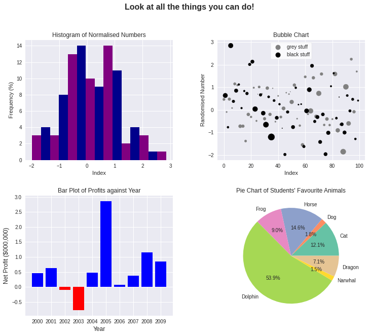

Remember, when you're asked to visualise some data, there may be many correct responses - a scatter plot may be just as useful as a histogram, or a pie chart might make as much sense as a stacked bar chart.

Likewise, many plots may be unsuitable for certain data - for example, if you need to show the distribution of data with thousands of datapoints, a scatter plot would create overlaps that would hide the true distribution, so a histogram or box plot would be better here. Before you dive into coding your plots, make sure you've chosen the appropriate type.

Visualisations are primarily used to convey relevant information in a concise way, so we don't want to overload the viewer with a lot of values. A good question to ask yourself is: if my chart didn't have many numbers, would it still convey the message I want it to? If the answer is no, you might be taking the wrong approach.

Here's a quick guide to the various types of charts you have available to you. You may also create charts that we haven't listed here, but make sure that they're easy to understand. Unfortunately we can't give a tutorial on each of the charts (or this lab would be extremely long), but there are plenty of online resources such as [the Matplotlib Gallery](https://matplotlib.org/gallery.html), and the `help(plt)` function can guide you as well.

**Do you want to compare values?** If you need to compare one or many value sets, and need to visualize the lows and highs in the data sets, you would need:

- **Column Chart** (`plt.bar`, [documentation](https://matplotlib.org/3.1.1/api/_as_gen/matplotlib.pyplot.bar.html)): A column chart is used to show a comparison among different items. While this looks similar to a histogram, it shouldn't be used to show distribution.
- **Side-by-side Column Chart** (`plt.bar(1,h1,w), plt.bar(1+w,h2,w)`, [documentation](https://matplotlib.org/3.1.1/api/_as_gen/matplotlib.pyplot.bar.html)): Like a column chart, but it has multiple columns for each x. This should be used to compare items across different x values AND within the same x value.
- **Bar Plot** (`plt.barh`, [documentation](https://matplotlib.org/3.1.1/api/_as_gen/matplotlib.pyplot.barh.html)): A bar graph, basically a horizontal column chart, should be used to avoid clutter when one data label is long or if you have more than 10 items to compare. This type of visualization can also be used to display negative numbers.
- **Line Plot** (`plt.plot`, [documentation](https://matplotlib.org/3.1.1/api/_as_gen/matplotlib.pyplot.plot.html)): A line graph reveals trends or progress over time and can be used to show many different categories of data. You should use it when you chart points that are related to neighbouring points, such as a time series. It shouldn't be used for independent datapoints.
- **Scatter Plot** (`plt.scatter`, [documentation](https://matplotlib.org/api/_as_gen/matplotlib.pyplot.scatter.html)): A scatter plot will show the relationship between two different variables or it can reveal the distribution of the y variable as the x value changes. It should be used when there are many different data points, and you want to highlight similarities in the data set. It's also useful when looking for outliers or for understanding the distribution of your data. It shouldn't be used to show the distribution if the x value is irrelevant.

**Do you want to show the composition of something?** Use this type of chart to show how individual parts make up the whole of something:

- **Pie Chart** (`plt.pie`, [documentation](https://matplotlib.org/3.1.1/api/_as_gen/matplotlib.pyplot.pie.html)): A pie chart shows a static percentages and how categories represent part of a whole. A pie chart represents numbers in percentages, and the total sum of all segments needs to equal 100%. Do not use this if you have more than 10 or so categories (you can combine many into an 'Other' category if this helps), or when the percentages are similar. Remember, if you exclude the percentages from your graph, does it still prove your point?
- **Stacked Column Chart** (`plt.bar(x1,h1), plt.bar(x2,h2,bottom=h1)`, [documentation](https://matplotlib.org/3.1.1/api/_as_gen/matplotlib.pyplot.bar.html)): This should be used to compare many different items across different x values (usually year or category), and show the composition of each item being compared. This shouldn't be used if you're trying to compare items within the same x value.
- **Area Chart** (`plt.stackplot`, [documentation](https://matplotlib.org/3.1.0/api/_as_gen/matplotlib.pyplot.stackplot.html)): An area chart is basically a line chart, but the space between the x-axis and the line is filled with a color or pattern. It is useful for showing part-to-whole relations. It helps you analyze both overall and individual trend information. These should be used cautiously, as it can be unclear whether the data is stacked or overlapping.

**Do you want to understand the distribution of your data?** Distribution charts help you to understand outliers, the normal tendency, and the range of information in your values.

- **Scatter Plot** (`plt.scatter`, [documentation](https://matplotlib.org/api/_as_gen/matplotlib.pyplot.scatter.html)): In addition to the description about scatter plots earlier, scatter plots are especially useful to show the location of outliers (in terms of both x and y), and how the distribution changes as x increases.
- **Box Plot** (`plt.boxplot`, [documentation](https://matplotlib.org/api/_as_gen/matplotlib.pyplot.boxplot.html)): A boxplot is a way to show the distribution of one-dimensional data based on the five-number summary: minimum, first quartile, median, third quartile, and maximum. This type of plot can also show outliers, and you can create side-by-side boxplots to compare distributions between categories (eg. height of each gender).
- **Histogram** (`plt.hist`, [documentation](https://matplotlib.org/3.1.1/api/_as_gen/matplotlib.pyplot.hist.html)): A histogram is an accurate representation of the distribution of numeric data. To create a histogram, first we divide the entire range of values into a series of intervals (or 'bins'), and second we count how many values fall into each interval. The bins are consecutive and non-overlapping intervals of a variable.

**Do you want to better understand the relationship between value sets?** Relationship charts are suited to showing how one variable relates to one or numerous different variables. You could use this to show how something positively effects, has no effect, or negatively effects another variable.

- **Scatter Plot**, **Coloured Scatter Plot** (`plt.scatter(c=colours)`, [documentation](https://matplotlib.org/api/_as_gen/matplotlib.pyplot.scatter.html)) or **Bubble Chart** (`plt.scatter(s=size)`, [documentation](https://matplotlib.org/api/_as_gen/matplotlib.pyplot.scatter.html)): A coloured scatter or bubble chart is similar to a normal scatter plot in that it can show distribution or relationship, but it includes a third data set, which is indicated by the colour / size of the bubble. Try not to create a coloured bubble chart - that's usually too much to interpret for the viewer.

We've waffled on long enough. Time for some exercises!

We'll be using an Airline Satisfaction dataset, which contains the responses to surveys of passengers based on a few different categories. Here's a description of all the columns:

| Name | Description |
| --- | --- |
| `gender` | gender of the passenger; "Male" or "Female" |
| `age` | age of the passenger in years |
| `class` | class of the passenger's ticket; "Eco", "Eco Plus" or "Business" |
| `seat_comfort` | passenger's rating of seat comfort on a scale of 1-5, integer only |
| `checkin_service` | passenger's rating of service at check-in on a scale of 1-5, integer only |
| `inflight_service` | passenger's rating of in-flight service on a scale of 1-5, integer only |
| `cleanliness` | passenger's rating of cleanliness during flight on a scale of 1-5, integer only |
| `dep_delay` | delay of passenger's flight departure in minutes |
| `arr_delay` | delay of passenger's flight arrival in minutes |

## Question 1: Analysing Graphs

To help you realise the pitfalls of certain visualisations (and thus help you choose the correct plot to use when you need to visualise data), we'll show you some graphs and you can decide whether they're appropriate. As this is primarily a discussion question, we encourage you to compare your answers with your neighbours or with your lab demonstrator.

Given a dataset of satisfaction scores, we want to compare scores between categories, as well as scores within each category. Visualisation will help us here, but we need to figure out what the best visualisation to use is.

### Q1.1: Scatter Plot

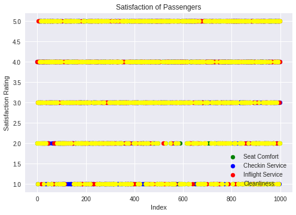

Hopefully, this should be easy to answer - there are a few obvious issues with it.

TODO: list two issues with the scatter plot 1. Cleanliness category covers all other categories, so this is useless for other categories 2. Does not actually show the distribution of any category 3. Index is an arbitrary numbering that doesn't affect the distribution, so including it causes unnecessary confusion

### Q1.2: Side-by-Side Boxplot

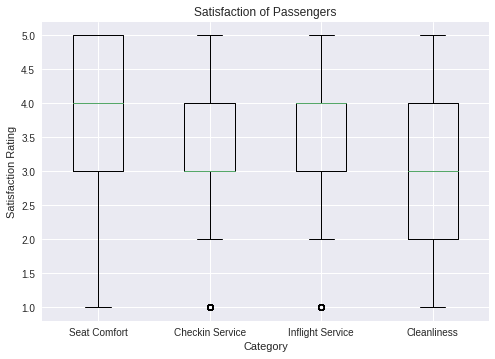

TODO: list two issues with the side-by-side boxplot 1. Because the boxplot lines are always on an integer (because the ratings are integer), it shows an inaccurate overview of the distributions. Because of this, some categories (eg. Checkin Service, Inflight Service) would appear almost identical, when we know that they do not have identical distributions. 2. Because the outliers overlap, the plot makes it seem like there is only one outlier for categories Checkin Service and Inflight Service, which is misleading.

### Q1.3: Stacked Column Chart

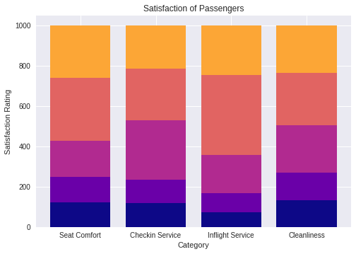

We're certainly getting closer, but this plot still has a missing part (which is quite essential), and isn't quite appropriate for the data. Describe what pitfalls it may have and give an example of a comparison that this plot would not be useful for. As an extra challenge, add code to the above block to include the missing part appropriately (i.e. without covering information in the plot).

TODO: describe what pitfalls it may have and give an example of a comparison that this plot would not be useful for While it's useful to compare between categories with large differences, small differences can be hard to identify, and this is especially true when comparing within categories. For example, compare Rating=4 for Checkin Service and Cleanliness - which is larger? What about comparing Rating=3 and Rating=4 for Cleanliness? Depending on what the comparisons are used for, these answers might be important.

### Q1.4: Side-by-Side Column Chart

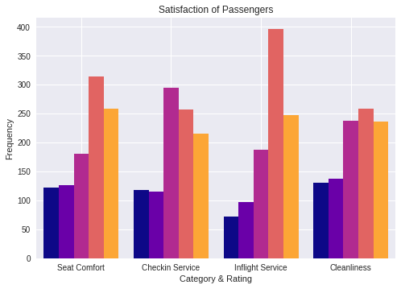

We've come up with this chart as the best way to compare between categories, as well as within categories. It's still missing something, which we challenge you to add to the plot to perfect it. Of course, it may still have some issues, and we accept that any plot we create may not be perfect - so we also challenge you to find errors in our plot and, more importantly, see if you can produce a better one.

TODO: what else may be missed in the side-by-side column chart? This is useful for comparing between categories, and also within categories. For example, you can easily tell that there are fewer points with Rating=3 than Rating=4 for Cleanliness. From a glance, you can also tell the modal rating (i.e. most common rating) for each category, by simply looking at the highest bars. This plot is still missing a legend, or alternatively x-subticks for each rating level. The code below rectifies this by creating a legend. Alternatively, you could move the x labels down and include "1 2 3 4 5 1 2 3 4 5 ..." associating with each bar.

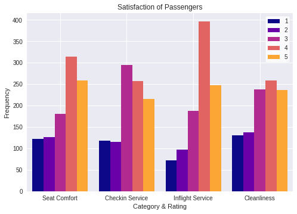

## Question 2: Your Own Visualisations

### Q2.1: Seat Comfort

Using the same dataset of airline passenger satisfaction ratings, we want to visualise how age affects seat comfort rating. Most importantly, we want to compare the mean or median across different age groups:

| Age Group | Ages |
| --- | --- |
| 0-17 | Child |
| 18-24 | Young Adult |
| 25-34 | Middle-Aged Adults |
| 35-59 | Older Adults |
| 60+ | Senior Adults |

We also want to visualise the distribution in each age group (which you can show as a range, as quartiles, or any other way you choose), and if applicable any outliers in the age groups. Finally, add titles, labels and colours to the plot to make it visually appealing (without making it harder to read or understand).

If you'd like, you can adjust, add, or combine any of the above age groups *if you believe there is reason to do so* (eg. if an age group varies considerably, or if there are too few responses in a particularly group). Make sure you have a minimimum of 4 groups and a maximum of 6 groups.

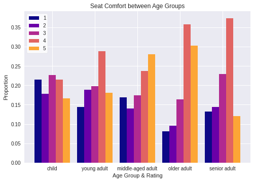

### Q2.2: All Categories

Now that you've visualised the data for one category, can you extend it to visualise all categories in one plot? Depending on which plot you used in the previous question, you may find it useful to use a different type of chart for this. We mainly want to compare the means (or medians) both *between* age groups (eg. seat comfort rating between children and young adults) and *within* age groups (eg. seat comfort rating versus cleanliness rating for older adults). If you can include a distribution measure and make it look visually appealing, that's an added bonus.

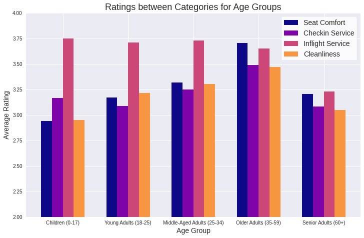

## Question 3: Hypothesising Happiness

Hypothesis testing is a statistical method used to determine whether data differs *significantly* from some baseline or another set of data. For example, if we have both males and females running in a race and have recorded their record times, we may want to see whether there is a significant difference in the running speed between genders. Alternatively, if someone claims that the average running speed of males is 15km/h, we may want to see if we have evidence to reject that claim.

Hypothesis tests follow a fairly rigorous structure.

1. First, we create a **null hypothesis ($H_0$)** and an **alternate hypothesis ($H_A$)**. The null hypothesis represents the 'default', which is assuming that the claim is true (eg. running speeds are equivalent between genders, or the running speed average is equal to 15km/h), and the alternate hypothesis is the opposite of that (eg. running speeds not equivalent).
2. Using our data, we calculate a **test statistic** or, similarly, a **p-value** which summarises the data in relation to the hypothesis you're testing.
3. By comparing our test statistic to a calculated cutoff, or similarly comparing the p-value to the chosen **significance level ($\alpha$)** (by default, $\alpha$=0.05), we can conclude whether we **reject the null hypothesis** (i.e. $p < \alpha$) or **fail to reject the null hypothesis** (note that we do not "accept" the null hypothesis in any case).
4. From the conclusion of our test, we can see whether the claim is accurate or not, and report our findings.

Thankfully, the SciPy package does most of the work for us - we just need to figure out which function to call depending on the type of question we want to answer. Each of the following returns a tuple with `(test_statistic, p_value)`.

| Function | Description |
| --- | --- |
| `stats.ttest_1samp` | performs a hypothesis test for the mean of *one* group of scores (against a baseline) eg. claiming a student's average mark is 76% |
| `stats.ttest_ind`, `stats.ttest_ind_from_stats` | performs a hypothesis test for the mean between *two independent* groups of scores eg. claiming the average marks between two similar courses are the same |
| `stats.ttest_rel` | performs a hypothesis test for the mean between *two related* groups of scores eg. claiming that a particular student's average marks in two different courses are the same |

Let's revisit our airline passenger satisfaction data.

|  | gender | age | class | seat_comfort | checkin_service | inflight_service | cleanliness | dep_delay | arr_delay |
| --- | --- | --- | --- | --- | --- | --- | --- | --- | --- |
| 0 | Male | 31 | Eco | 2 | 4 | 4 | 2 | 0 | 0.0 |
| 1 | Male | 8 | Eco | 1 | 4 | 4 | 1 | 18 | 13.0 |
| 2 | Female | 35 | Business | 3 | 1 | 3 | 3 | 0 | 0.0 |
| 3 | Female | 27 | Business | 3 | 4 | 5 | 3 | 24 | 23.0 |
| 4 | Male | 23 | Business | 2 | 3 | 4 | 2 | 0 | 0.0 |

Suppose we want to determine whether the check-in service rating differs between Economy (Eco) and Business passengers. First, let's create our hypotheses:

$H_0$: Check-in service rating is equivalent between Economy and Business passengers; $H_A$: Check-in service rating is different between Economy and Business passengers.

Now we determine which of the SciPy functions to call. As we're dealing with two groups of scores (Economy and Business), and the scores are unrelated (different passengers are in each, so scores are independent), we would use the `stats.ttest_ind` function.

```
p-value: 1.192749747150937e-05
```

We see that the p-value is very small (e-05 is equivalent to $\times 10^{-5}$, so $p=0.00001193$), and because it is less than $\alpha=0.05$, it lies in the **rejection region**. Thus we **reject the null hypothesis**; we have sufficient data to indicate that the check-in service rating is *statistically different* between Economy and Business passengers.

### Q3.1 Comparing Cleanliness Rating based on Departure Delay

Alex believes that airline passengers give different ratings if their flight is delayed, even if otherwise the actual service may not be any different. This might be because the passengers are grumpy, so it affects their feelings for the rest of the flight.

To check this, please perform a hypothesis test (you'll need to determine which hypothesis test is most appropriate between one-sample, independent or related) for cleanliness rating based on two groups: passengers whose flight was not delayed at all (`dep_delay == 0`), and passengers whose flight was delayed (`dep_delay != 0`).

TODO: create null hypothesis (H0) and alternate hypothesis (HA) H0: cleanliness rating is equivalent between non-delayed and delayed flights HA: cleanliness rating differs dependent on whether the flight was delayed

```
p-value: 0.07792123771600831
```

TODO: discuss results and reach conclusion p-value is greater than 0.05 so it does not lie in the rejection region, thus we fail to reject the null hypothesis and decide that the cleanliness rating is equivalent between non-delayed and delayed flights.

### Q3.2 Comparing In-Flight Service Ratings and Check-in Service Ratings

Ben thinks that passengers rate in-flight service around the same that they rate check-in service, because these both reflects the service of the airline.

Before running a hypothesis test, first look at the means, the standard deviations of the differences between in-flight service and check-in service, and the number of samples, and then decide for yourself whether you think that these are *statistically equivalent*. (i.e. that the means are pretty much the same)

```
Check-in Service Rating Mean: 3.336
In-Flight Service Rating Mean: 3.649
Standard Deviation of the differences between Check-in and In-Flight Service Rating : 1.4411908270593348
Total # of Samples: 1000
```

TODO: are they statistically equivalent? why? (This question has no unique answer) Although the std of the differences is relatively large when compared with the mean differences (3.649-3.336=0.313), but the number of samples is around 3 order of magnitude larger than the std. I would say the mean difference is very likely to be significant.

Now run a hypothesis test for two groups - `checkin_service` and `inflight_service` (again, you must determine which test is most suitable). Be sure to include all the steps in your test (as we'll be expecting all steps for future assessment).

TODO: list your hypothesis here H0: check-in service rating and in-flight service rating are equivalent HA: there is a significant difference between the way passengers rate check-in service and in-flight service

```
p-value: 1.1704265750804061e-11
True
```

As the p-value is (far) below 0.05, we reject the null hypothesis: there is a statistically significant difference between check-in service rating and in-flight service rating

Does the answer from the hypothesis test you just ran match the guess you made before? Why or why not? You might like to discuss this with your tutor or classmates.

TODO: does the conclusion match your guess? Yes, the guess and the conclusion match.

### Q3.3 Checking Average Age of Passengers

For simplicity in reporting, Afzal wants to claim that the average age of passengers is 40 years. As before, first look at the mean, standard deviation, and the number of samples of the age of passengers and decide whether this is "close enough" to 40. Then run a hypothesis test, ensuring that you include all steps. Does your guess match the conclusion from the hypothesis test? Why or why not?

```
Mean of Age: 39.04
Standard Deviation of Age: 15.38
# of Samples: 1000
```

Given that the difference between 39.04 and 40 is less than 1, and the standard deviation of age is around 15 times larger than the difference, it seems like the difference is not be significant. But the number of sample is also very large, so it is hard to conclude. H0: average age of passengers is 40 years old HA: average age of passengers is significantly different from 40 years old

```
p-value: 0.048254656965650296
```

The p-value is (barely) below 0.05, so we reject the null hypothesis: the average age of passengers is not 40 years old. The p-value is near the 0.05 cutoff this isn't too surprising.

## Homework & Extension Questions

We suggest that you finish the previous questions before moving on to the extension questions.

### Q4: Adding to a previous plot

In Q1.4, we challenged you to add a missing piece (which was either a legend or sub-labels on the x-axis under each bar indicating each rating level). We also suggested that you adjust the plot if you thought it wasn't sufficient.

In addition to the above, we'd also like to include the mean in the plot (not necessarily for comparison). You can do this however you'd like, but if you're stuck for ideas you can use `plt.vlines()` to create vertical lines in the plot.

We've included the same code as above here for your convenience.

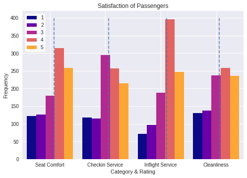

### Q5: One-Sided Hypothesis Test

In Q3.1, you would have run a test to determine whether passengers give *different* ratings depending on whether their flight was delayed - this is a two-tailed test (i.e. the alternate hypothesis includes the possibility that it is either higher or lower). However, we'd really expect ratings to be *lower* if a passenger's flight is delayed - this is a **one-sided hypothesis test**.

Running a one-sided test is fairly similar to a two-tailed test, except that we adjust the alternate hypothesis and **halve the resulting p-value** before interpreting its value. You will also need to confirm that the side you are checking is accurate (in this case, check that the cleanliness rating mean is lower for delayed flights than non-delayed flights).

Run a one-sided hypothesis test to determine whether the cleanliness rating is *lower* if the flight was delayed. We've written up the hypotheses to guide you.

*Hint: you should reach a different conclusion to the two-tailed test.*

H0: cleanliness rating is equivalent regardless of whether a flight is delayed or not HA: cleanliness rating is lower if a flight is delayed

```
One-sided p-value: 0.038960618858004156
```

Now, since the p-value is lower than 0.05, we reject the null hypothesis; cleanliness rating is lower if a flight is delayed.